# Project Code

#### 2.4.3 Vaccination statuses

The intention with this section is to understand the relationship of vaccination statuses on heart attacks and quantify whether there is or is not an relationship.

```python
def scrape_tetanus(string):
    if "Yes" in string:
        return "Yes"
    else:
        return "No"
```

```python
tetanus_notna_data = f_heart_data[f_heart_data["TetanusLast10Tdap"].notna()].copy()
```

```python
new_tetanus = tetanus_notna_data["TetanusLast10Tdap"].apply(lambda x: scrape_tetanus(x)).to_list()
tetanus_notna_data["TetanusLast10Tdap"] = new_tetanus
```

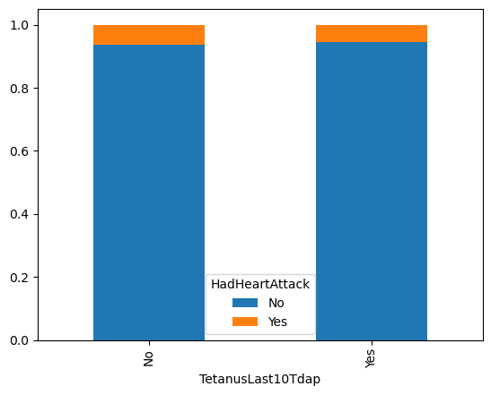

```python
c1table = pd.crosstab(tetanus_notna_data['TetanusLast10Tdap'], tetanus_notna_data["HadHeartAttack"], normalize = 'index')
ax = c1table.plot(kind='bar', stacked=True)
plt.show()
```

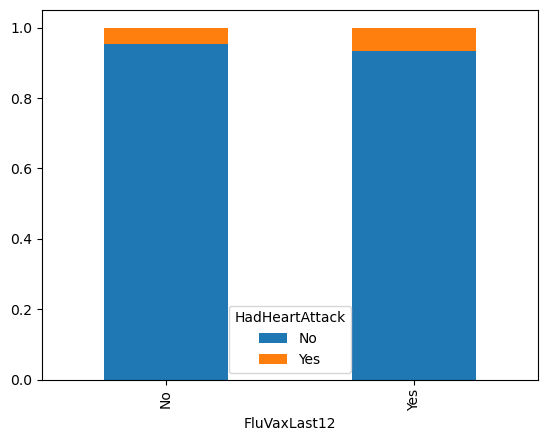

```python
ctable = pd.crosstab(f_heart_data['FluVaxLast12'], f_heart_data["HadHeartAttack"], normalize = 'index')
ax = ctable.plot(kind='bar', stacked=True)
plt.show()
```

```python
#Interesting that there are slightly more heart attacks with the flu vax, maybe confounding variable?
f_heart_data.groupby("AgeCategory")["FluVaxLast12"].value_counts()
```

```
AgeCategory      FluVaxLast12
Age 18 to 24     No              15786
                 Yes              7671
Age 25 to 29     No              12652
                 Yes              6556
Age 30 to 34     No              14177
                 Yes              8073
Age 35 to 39     No              15272
                 Yes              9475
Age 40 to 44     No              15559
                 Yes             10370
Age 45 to 49     No              14294
                 Yes             10356
Age 50 to 54     No              16253
                 Yes             12866
Age 55 to 59     No              16155
                 Yes             15978
Age 60 to 64     Yes             21842
                 No              17358
Age 65 to 69     Yes             27143
                 No              14867
Age 70 to 74     Yes             27240
                 No              11727
Age 75 to 79     Yes             21389
                 No               7673
Age 80 or older  Yes             23862
                 No               8191
Name: count, dtype: int64
```

```python
age_categories = ['Age 18 to 24', 'Age 25 to 29', 'Age 30 to 34', 'Age 35 to 39',
                       'Age 40 to 44', 'Age 45 to 49', 'Age 50 to 54', 'Age 55 to 59',
                       'Age 60 to 64', 'Age 65 to 69', 'Age 70 to 74', 'Age 75 to 79', 'Age 80 or older']
```

```python
def plot_age_proportion(age, variable):
    table = pd.crosstab(f_heart_data[f_heart_data["AgeCategory"] == age][variable], f_heart_data["HadHeartAttack"], normalize = 'index')
    ax = table.plot(kind='bar', stacked=True)
    plt.show()
```

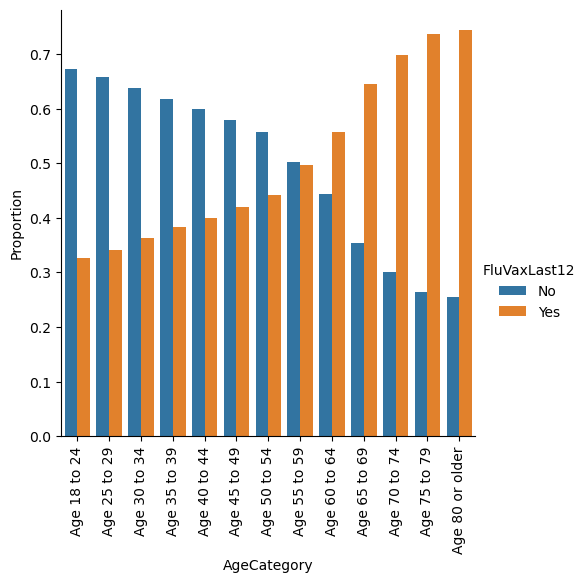

```python
#Indication of some relationship between potential confounding variable age, let's visualize!
f_heart_data.groupby("AgeCategory")["FluVaxLast12"].value_counts(normalize = True).rename('Proportion').reset_index().pipe((sns.catplot,'data'), x="AgeCategory",y='Proportion',hue="FluVaxLast12",kind='bar')
plt.xticks(rotation=90)
plt.show()
```

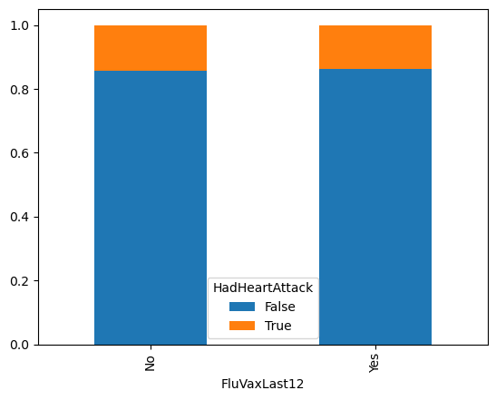

```python
plot_age_proportion('Age 80 or older', 'FluVaxLast12')
```

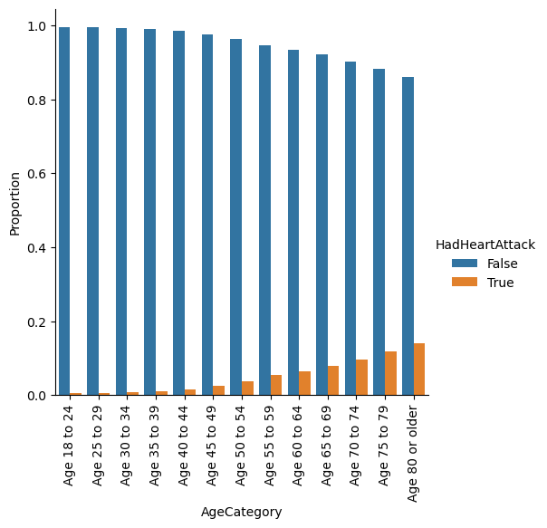

```python
f_heart_data.groupby("AgeCategory")["HadHeartAttack"].value_counts(normalize = True).rename('Proportion').reset_index().pipe((sns.catplot,'data'), x="AgeCategory",y='Proportion',hue="HadHeartAttack",kind='bar')
plt.xticks(rotation=90)
plt.show()
```

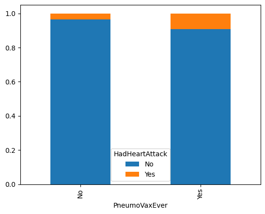

```python
c2table = pd.crosstab(f_heart_data['PneumoVaxEver'], f_heart_data["HadHeartAttack"], normalize = 'index')
ax = c2table.plot(kind='bar', stacked=True)
plt.show()
```

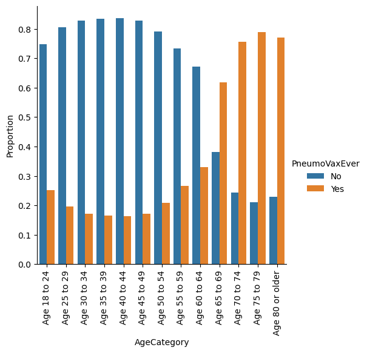

```python
f_heart_data.groupby("AgeCategory")["PneumoVaxEver"].value_counts(normalize = True).rename('Proportion').reset_index().pipe((sns.catplot,'data'), x="AgeCategory",y='Proportion',hue="PneumoVaxEver",kind='bar')
plt.xticks(rotation=90)
plt.show()
```

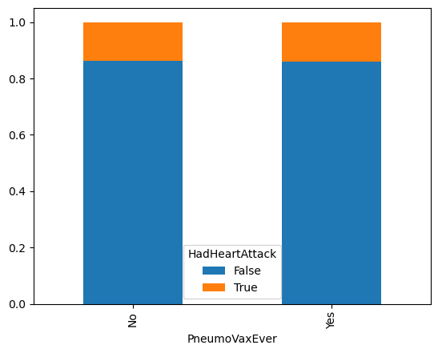

```python
plot_age_proportion('Age 80 or older', 'PneumoVaxEver')
```

#### 2.4.4 Underlying conditions

The intention with this section is to understand the relationship of underlying conditions on heart attack likelihood, namely which conditions have the greatest relationship on heart attack likelihood.

HEART DISEASES

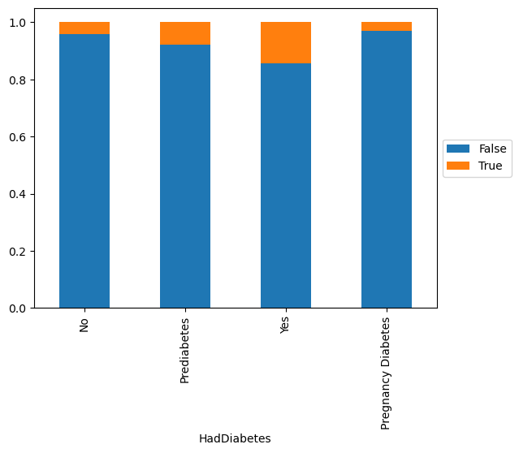

```python
c4table = pd.crosstab(f_heart_data['HadDiabetes'], f_heart_data["HadHeartAttack"], normalize = 'index')
ax = c4table.plot(kind='bar', stacked=True)
ax.legend(loc='center left', bbox_to_anchor=(1, 0.5))
plt.xticks(range(0, 4), ['No', 'Prediabetes', 'Yes', 'Pregnancy Diabetes'])
plt.show()
```

```python
f_heart_data.groupby("HadDiabetes")["HadHeartAttack"].value_counts()
```

```
HadDiabetes                              HadHeartAttack
No                                       False             346561
                                         True               15234
No, pre-diabetes or borderline diabetes  False               9110
                                         True                 762
Yes                                      False              50872
                                         True                8468
Yes, but only during pregnancy (female)  False               3650
                                         True                 109
Name: count, dtype: int64
```

```python
c4table
```

| HadHeartAttack HadDiabetes | False | True |
| --- | --- | --- |
| No | 0.957893 | 0.042107 |
| No, pre-diabetes or borderline diabetes | 0.922812 | 0.077188 |
| Yes | 0.857297 | 0.142703 |
| Yes, but only during pregnancy (female) | 0.971003 | 0.028997 |

```python
diabetes_yes_count = 9110+762+50872+8468
diabetes_no_count = 346561+15234

print((762+8468)/diabetes_yes_count)
print(15234/diabetes_no_count)
print("Diff = ", ((762+8468)/diabetes_yes_count)- 15234/diabetes_no_count)
print("mult =", (((762+8468)/diabetes_yes_count)- 15234/diabetes_no_count)/(15234/diabetes_no_count))
```

```
0.13335837716003004
0.04210671789272931
Diff =  0.09125165926730074
mult = 2.1671520325989935
```

Individuals with diabetes are more than twice as likely to have heart attacks.

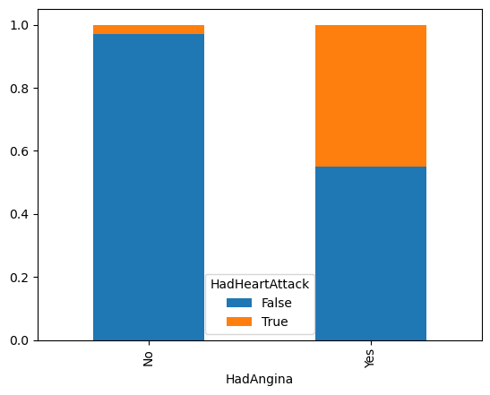

```python
c3table = pd.crosstab(f_heart_data['HadAngina'], f_heart_data["HadHeartAttack"], normalize = 'index')
ax = c3table.plot(kind='bar', stacked=True)
plt.show()
```

```python
c3table
```

| HadHeartAttack HadAngina | False | True |
| --- | --- | --- |
| No | 0.971140 | 0.028860 |
| Yes | 0.549902 | 0.450098 |

```python
0.450098/0.028860
```

```
15.595911295911296
```

Individuals with Angina are 15.6 times more likely to suffer a heart attack than individuals without

MISCELLANEOUS

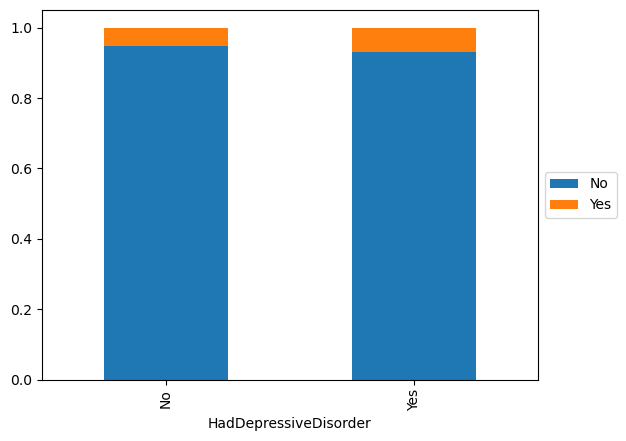

```python
c5table = pd.crosstab(heart_data['HadDepressiveDisorder'], heart_data["HadHeartAttack"], normalize = 'index')
ax = c5table.plot(kind='bar', stacked=True)
ax.legend(loc='center left', bbox_to_anchor=(1, 0.5))
plt.show()
```

```python
c5table
```

| HadHeartAttack HadDepressiveDisorder | No | Yes |
| --- | --- | --- |
| No | 0.946822 | 0.053178 |
| Yes | 0.929744 | 0.070256 |

```python
0.070256/0.053178
```

```
1.3211478430930084
```

Individuals with depressive disorders are 32% more likely to suffer from heart attacks.

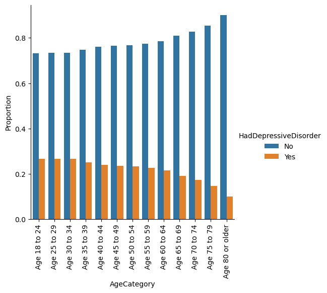

```python
f_heart_data.groupby("AgeCategory")["HadDepressiveDisorder"].value_counts(normalize = True).rename('Proportion').reset_index().pipe((sns.catplot,'data'), x="AgeCategory",y='Proportion',hue="HadDepressiveDisorder",kind='bar')
plt.xticks(rotation=90)
plt.show()
```

Probably even more due to lesser old people having depressive disorders.

```python
f_heart_data.groupby("AgeCategory")[['HadDepressiveDisorder', "HadHeartAttack"]].value_counts()
```

```
AgeCategory      HadDepressiveDisorder  HadHeartAttack
Age 18 to 24     No                     False             18998
                 Yes                    False              6890
                 No                     True                 60
                 Yes                    True                 59
Age 25 to 29     No                     False             15551
                 Yes                    False              5635
                 No                     True                 65
                 Yes                    True                 48
Age 30 to 34     No                     False             18273
                 Yes                    False              6547
                                        True                 96
                 No                     True                 84
Age 35 to 39     No                     False             20620
                 Yes                    False              6822
                                        True                157
                 No                     True                148
Age 40 to 44     No                     False             21936
                 Yes                    False              6756
                 No                     True                214
                 Yes                    True                208
Age 45 to 49     No                     False             20773
                 Yes                    False              6211
                 No                     True                392
                 Yes                    True                306
Age 50 to 54     No                     False             24349
                 Yes                    False              7062
                 No                     True                688
                 Yes                    True                512
Age 55 to 59     No                     False             26494
                 Yes                    False              7387
                 No                     True               1186
                 Yes                    True                720
Age 60 to 64     No                     False             32146
                 Yes                    False              8425
                 No                     True               1930
                 Yes                    True                889
Age 65 to 69     No                     False             34582
                 Yes                    False              7844
                 No                     True               2632
                 Yes                    True                967
Age 70 to 74     No                     False             31968
                 Yes                    False              6421
                 No                     True               3204
                 Yes                    True                917
Age 75 to 79     No                     False             24107
                 Yes                    False              3930
                 No                     True               2998
                 Yes                    True                705
Age 80 or older  No                     False             27645
                                        True               4328
                 Yes                    False              2910
                                        True                611
Name: count, dtype: int64
```

```python
f_interested_variables = f_heart_data.loc[:, ["BMI", "State", "AgeCategory", "HadHeartAttack", "HadAngina", "HadDepressiveDisorder", "HadDiabetes", "PneumoVaxEver", "FluVaxLast12", "TetanusLast10Tdap"]]
```

```python
for variable in ["BMI", "State", "AgeCategory", "HadHeartAttack", "HadAngina", "HadDepressiveDisorder", "HadDiabetes", "PneumoVaxEver", "FluVaxLast12", "TetanusLast10Tdap"]:
    print(f_interested_variables[variable].describe())
```

```
count    435826.000000
mean         28.522780
std           6.187556
min          12.020000
25%          24.410000
50%          27.960000
75%          31.010000
max          99.640000
Name: BMI, dtype: float64
count     435826
unique        51
top           WA
freq       26152
Name: State, dtype: object
count           426866
unique              13
top       Age 65 to 69
freq             46222
Name: AgeCategory, dtype: object
count     435826
unique         2
top        False
freq      411177
Name: HadHeartAttack, dtype: object
count     431482
unique         2
top           No
freq      405401
Name: HadAngina, dtype: object
count     433044
unique         2
top           No
freq      343024
Name: HadDepressiveDisorder, dtype: object
count     434766
unique         4
top           No
freq      361795
Name: HadDiabetes, dtype: object
count     359963
unique         2
top           No
freq      209131
Name: PneumoVaxEver, dtype: object
count     389253
unique         2
top          Yes
freq      206205
Name: FluVaxLast12, dtype: object
count                                                354651
unique                                                    4
top       No, did not receive any tetanus shot in the pa...
freq                                                 116876
Name: TetanusLast10Tdap, dtype: object
```

```python
tetanus_notna_data["TetanusLast10Tdap"].describe()
```

```
count     362616
unique         2
top          Yes
freq      241123
Name: TetanusLast10Tdap, dtype: object
```

```python
f_interested_variables["FluVaxLast12"].isna().sum()
```

```
46573
```

```python
f_interested_variables["FluVaxLast12"].value_counts()
```

```
FluVaxLast12
Yes    206205
No     183048
Name: count, dtype: int64
```